# Reading the dataset

# Insights:

- People with 18 years of education are more likely to prefer advanced KP781 trademill.
- Customers with eduction less than 18 years more likely to prefer kp281 and KP481.

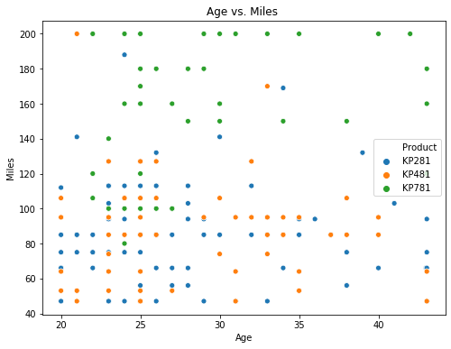

```python
# Scatter plot for 'Age' vs. 'Miles' for different products
plt.figure(figsize=(8, 6))
sns.scatterplot(x='Age_clipped', y='Miles_clipped', data=df,hue='Product')
plt.title('Age vs. Miles ')
plt.xlabel('Age')
plt.ylabel('Miles')
plt.show()
```

## Insights:

1. Customers with more than 140 miles per week will prefer KP781.
2. Customers with lower average miles per week are more likely to buy KP-281 & KP-481.

## Representing the Probability

# Contingeny Table : Product VS Gender

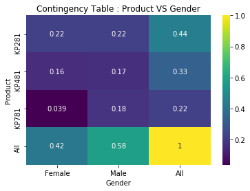

```python
contingency_table=pd.crosstab(index=df['Product'], columns=df['Gender'], values=None, rownames=None, colnames=None, aggfunc=None, margins=True, normalize=True)
sns.heatmap(contingency_table,annot=True,cmap='viridis')
plt.title('Contingency Table : Product VS Gender')
plt.show()
```

# Marginal Probabilities:

1. The probability that a customer will purchase KP281 is 44%.
2. The probability that a customer will purchase KP481 is 33%.
3. The probability that a customer will purchase KP781 is 22%.

## Conditional Probabilities : Given Gender = Male

```python
# Conditional Probabilty: P(KP781/Male)
round((0.18/0.58)*100,2)
```

```
31.03
```

```python
# Conditional Probabilty: P(KP481/Male)
round((0.17/0.58)*100,2)
```

```
29.31
```

1. Given the customer is male , the probability that he will buy KP-481 is 29%.

```python
# Conditional Probabilty: P(KP281/Male)
round((0.22/0.58)*100,2)
```

```
37.93
```

# Conditional Probabilities : Given Gender=Female

```python
# Conditional Probabilty: P(KP281/Female)
round((0.22/0.42)*100,2)
```

```
52.38
```

1. Given the customer is female , the probability that he will buy KP-281 is 52%.
1. So females are more likely to buy KP281 than their male counterparts.

```python
# Conditional Probabilty: P(KP481/Female)
round((0.16/0.42)*100,2)
```

```
38.1
```

1. Given the customer is female , the probability that he will buy KP-481 is 38%.
1. So females are more likely to buy KP481 than their male counterparts.

```python
# Conditional Probabilty: P(KP781/Female)
round((0.039/0.42)*100,2)
```

```
9.29
```

1. Given the customer is female , the probability that he will buy KP-781 is 9%.
1. So females are less likely to buy KP781 than their male counterparts.

# Contingeny Table : Product VS Marital Status

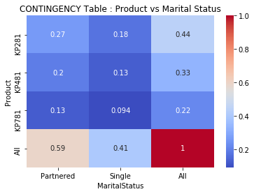

```python
contingency_table_ms=pd.crosstab(index=df['Product'], columns=df['MaritalStatus'], values=None, rownames=None, colnames=None, aggfunc=None, margins=True, normalize=True)
sns.heatmap(contingency_table_ms,annot=True,cmap='coolwarm')
plt.title('CONTINGENCY Table : Product vs Marital Status')
plt.show()
```

## Insights:

1. Probabilty that a married person will buy a fitness product is 59%.
2. Probabilty that a single person will buy a fitness product is 41%.

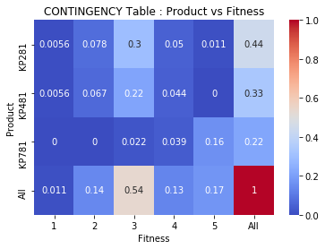

```python
contingency_table_ft=pd.crosstab(index=df['Product'], columns=df['Fitness'], values=None, rownames=None, colnames=None, aggfunc=None, margins=True, normalize=True)
sns.heatmap(contingency_table_ft,annot=True,cmap='coolwarm')
plt.title('CONTINGENCY Table : Product vs Fitness')
plt.show()
```

# Conditional Probabilities: Given Fitness level 5

```python
# Conditional Probabilty: P(KP781/Fitness=5)
round((0.16/0.17)*100,2)
```

```
94.12
```

- If a customer has fitness level 5 then the chance that he will buy Kp-781 is 94%.

```python
# Conditional Probabilty: P(KP281/Fitness=5)
round((0.011/0.17)*100,2)
```

```
6.47
```

- If a customer has fitness level 5 then the chance that he will buy Kp-281 is 6%.

# Conditional Probabilities: Given Fitness level 3

```python
# Conditional Probabilty: P(KP281/Fitness=3)
round((0.3/0.54)*100,2)
```

```
55.56
```

- If a customer has fitness level 3 then the chance that he will buy Kp-281 is 56%.

```python
# Conditional Probabilty: P(KP481/Fitness=3)
round((0.22/0.54)*100,2)
```

```
40.74
```

- If a customer has fitness level 3 then the chance that he will buy Kp-481 is 41%.

```python
# Conditional Probabilty: P(KP781/Fitness=3)
round((0.022/0.54)*100,2)
```

```
4.07
```

- If a customer has fitness level 3 then the chance that he will buy Kp-781 is 4%.

# Correlation Among multiple factors

```python
df=df.drop(['Age','Education','Income','Miles'],axis=1)
```

```python
corr=df.corr(numeric_only=True)
sns.heatmap(corr,cmap="Blues",annot=True)
plt.title('Correlation between numerical Variables')
plt.show()
```

[output not shown]

```python
sns.pairplot(data=df,hue='Product')
plt.title('Pairplot for each numerical column')
plt.show()
```

[output not shown]

## Customer profiling and recommendation

```python
# Bucketizing Age
bins = [0, 25,30,40, float('inf')]  # Adjust the bin edges as per your requirements
labels = ['18-25', '25-30', '30-40', '40+']

df['Age_Bucket'] = pd.cut(df['Age_clipped'], bins=bins, labels=labels, right=False)
```

```python
# Bucketizing Income
income_bins = [0, 30000, 50000, 70000, float('inf')]
income_labels = ['0-30k', '30k-50k', '50k-70k', '70k+']

df['Income_Bucket'] = pd.cut(df['Income_clipped'], bins=income_bins, labels=income_labels, right=False)
```

```python
contingency_table_cp=pd.crosstab(index=df['Product'], columns=df['Age_Bucket'], margins=True, normalize=True)
sns.heatmap(contingency_table_cp,annot=True,cmap='coolwarm')
plt.title('CONTINGENCY Table : Product Vs Age group')
plt.show()
```

[output not shown]

## Conditional probabilities = KP281: Given Age Group

1. Prob(KP281/AGE=18-25)=0.5
2. Prob(KP281/AGE=25-30)=0.42
3. Prob(KP281/AGE=30-40)=0.39
4. Prob(KP281/AGE=40+)=0.41

## Conditional probabilities = KP481: Given Age Group

1. Prob(KP481/AGE=18-25)=0.31
2. Prob(KP481/AGE=25-30)=0.27
3. Prob(KP481/AGE=30-40)=0.43
4. Prob(KP481/AGE=40+)=0.30

## Conditional probabilities = KP781: Given Age Group

1. Prob(KP781/AGE=18-25)=0.19
2. Prob(KP781/AGE=25-30)=0.28
3. Prob(KP781/AGE=30-40)=0.16
4. Prob(KP781/AGE=40+)=0.30

```python
contingency_table_inc=pd.crosstab(index=df['Product'], columns=df['Income_Bucket'], margins=True, normalize=True)
sns.heatmap(contingency_table_inc,annot=True,cmap='coolwarm')
plt.title('CONTINGENCY Table : Product Vs Income group')
plt.show()
```

[output not shown]

## Conditional probabilities- KP281:Given income group

1. Prob(KP281/Income=30-50k)=0.59
2. Prob(KP281/Income=50-70k)=0.44
3. Prob(KP281/Income=70k+)=0

## Conditional probabilities - KP481:Given income group

1. Prob(KP481/Income=30-50k)=0.37
2. Prob(KP481/Income=50-70k)=0.41
3. Prob(KP481/Income=70k+)=0

# Summarized Recommendations

# Customer Profiling : KP281

1. Gender: Females are more likely to buy this product comaped to male counterparts.
2. Income: Customers in the income range of 30k-50k are more likely to buy KP-281.
3. Age: Customers in the age group of 18-30 are more likely to buy KP281.
4. Other considerations: Customers with fitness level 1-3 are more likely to buy this product.

# Customer Profiling : KP481

1. Gender: Females are more likely to buy this product compared to male counterparts.
2. Income: Customers in the income range of 50k-70k are more likely to buy KP-481.
3. Age: Customers in the age group of 30-40 are more likely to buy this product.

# Customer Profiling : KP781

1. Gender: Males are more likely to buy this product comaped to female counterpart.
2. Income: Customers in the income range of 70k+ are most likely to buy KP-781.
3. Age: The age of a person doesn't really matter for this product. If someone is wealthy or very fit, they're likely to purchase it.
4. Other considerations: Customers with fitness level 4-5 or average 140 miles per week or average usage of more than 4 days per week are more likely to buy this product.